# Introduction to Text Anaysis and Natural Language Processing (in Python)

### Content for the first hour

- Who I am and what I do
- What NLP is and its application
- Intro to Google Colab (for those who do not have another coding environment on their machine)

## Lisa Andreevna Chalaguine

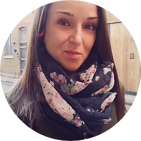

- did my PhD at University College London (currently writing up my thesis) in the Intelligent Systems Group
- developed chatbots that can engage in argumentative dialogues with people (e.g. convincing them to get a COVID-19 vaccine)
- since October working as an NLP Data Scientiest in a small startup in the LegalTech domain (dealing with UK and EU Regulations)
- still doing a lot of teaching on the side (mentoring high-school kids, helping university students with ML courseworks, and here at Oxford Uni)

## What is NLP

[figure not shown]

- Field of AI that gives machines the ability to read, understand and derive meaning from human language
- Not just string processing and keyword matching
- NLP combines computational linguistics—rule-based modeling of human language—with statistical, machine learning, and deep learning models. Together, these technologies enable computers to process human language in the form of text or voice data and to ‘understand’ its full meaning, complete with the speaker or writer’s intent and sentiment

## Applications of NLP

● Machine Translation (e.g. Google Translate

● Virtual Assistants (Siri, Alexa etc.)

● Information Extraction

● Summarisation

● Text Generation

● Question Answering

● Text Generation

● Sentiment Analysis

● Text Classification

● Auto Correct

[figure not shown]

## Challenges

● Unstructured data

● Ambiguity (lexial and structural)

● Synonyms

● Anaphora

● Sarcasm

● Coreference

[figure not shown]

### Lexical Ambiguity

Same words, different meaning (homographs)

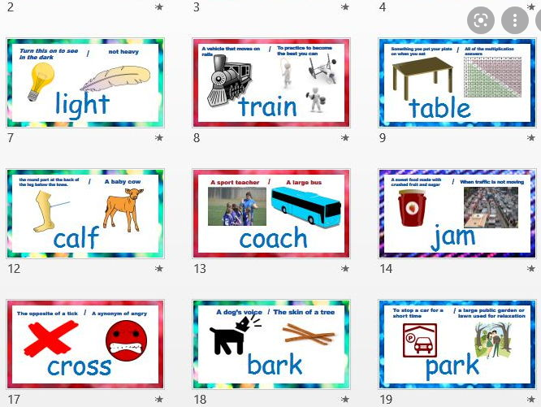

### Structural Ambiguity

[figure not shown]

#### Ambiguity Game: http://madlyambiguous.osu.edu/

### Synonymy

Same mearning, different words

[figure not shown]

#### Machine Reading: https://demo.allennlp.org/reading-comprehension/bidaf-elmo

### Language Change

Language constantly changes

#### Googles n-gram viewer: https://books.google.com/ngrams

### Figurative Speech

Ordinary sentences refering to something without explicitly stating it (metaphors, irony, sarcasm, hyperboles etc.)

#### sentiment analysis: https://demo.allennlp.org/sentiment-analysis/glove-sentiment-analysis